# Template voor het analyseren van RNA-seq data

Bas van Gestel

2026-03-14

# week 3: Alignment van RNA-seq data

# intdoductie

In dit project onderzoeken we welke genen verschillend tot expressie komen tussen het hersenweefsel en het leverweefsel. Om deze onderzoekvraag te beantwoorden analyseren we RNA-seq data van beide weefsels.De analyse bestaat uit meerdere stappen: eerste voeren we de alignment uit van de ruwe FASTQ-reads op het humane referentiegenoom (hg38), vervolgens tellen we het aantal reads per gen, en daarna bepalen we welke genen significant verschillend tot expressie zijn. De alignment vormt de basis voor alle vervolganalyses en is daarom een curciale stap in de workflow.

#Toelichting op de alignment analyse Voor de alignment maken we gebruik van de `align()`functie uit het Rsubread‑pakket. We werken met zes FASTQ‑bestanden: drie afkomstig uit het hersenweefsel (hersenen) en drie uit het leverweefsel (lever). Deze bestanden zijn opgeslagen op de server in `/home/data/opra4v/fastq/`. De alignment wordt uitgevoerd tegen het humane referentiegenoom hg38, waarvan de vooraf geïndexeerde bestanden beschikbaar zijn in `/home/data/opra4v/hg38_index/`. In de R‑code geven we het pad naar deze index door via het argument `index`. Omdat de FASTQ‑bestanden gecomprimeerd zijn, gebruiken we `input_format = "gzFASTQ"`. De output van de alignment bestaat uit BAM‑bestanden (`output_format = "BAM"`). Daarnaast kiezen we voor `unique = TRUE`, zodat alleen reads die uniek op het genoom uitgelijnd zijn (uniquely mapped) worden meegenomen. Dit verhoogt de betrouwbaarheid van de downstream analyses. De alignmentstatistieken worden opgeslagen in de variabele `alignment_statistics`, zodat we deze later kunnen gebruiken voor het berekenen van het percentage uniquely mapped reads en het maken van een grafiek.

```
## [1] "/home/data/opra4v/fastq/"
```

```
## [1] "/home/data/opra4v/fastq/"
```

```
## [1] "SRR7961196.fastq.gz" "SRR7961197.fastq.gz" "SRR7961198.fastq.gz"
## [4] "SRR7961208.fastq.gz" "SRR7961209.fastq.gz" "SRR7961210.fastq.gz"
## [7] "SRR7961214.fastq.gz" "SRR7961215.fastq.gz" "SRR7961216.fastq.gz"
```

```
## character(0)
```

#lever samples

#hersen samples

[output not shown]

[output cut: 249 more lines]

```
##
## //================================   Summary =================================\\
## ||                                                                            ||
## ||                 Total reads : 15602576                                     ||
## ||                      Mapped : 12224125 (78.3%)                             ||
## ||             Uniquely mapped : 12224125                                     ||
## ||               Multi-mapping : 0                                            ||
## ||                                                                            ||
## ||                    Unmapped : 3378451                                      ||
## ||                                                                            ||
## ||                      Indels : 42237                                        ||
## ||                                                                            ||
## ||                Running time : 3.9 minutes                                  ||
## ||                                                                            ||
## \\============================================================================//
```

```
## [1] "/home/data/opra4v/fastq//SRR7961208.fastq.gz"
## [2] "/home/data/opra4v/fastq//SRR7961209.fastq.gz"
## [3] "/home/data/opra4v/fastq//SRR7961210.fastq.gz"
```

[output not shown]

[output cut: 253 more lines]

```
##
## //================================   Summary =================================\\
## ||                                                                            ||
## ||                 Total reads : 15368537                                     ||
## ||                      Mapped : 8707141 (56.7%)                              ||
## ||             Uniquely mapped : 8707141                                      ||
## ||               Multi-mapping : 0                                            ||
## ||                                                                            ||
## ||                    Unmapped : 6661396                                      ||
## ||                                                                            ||
## ||                      Indels : 20310                                        ||
## ||                                                                            ||
## ||                Running time : 2.2 minutes                                  ||
## ||                                                                            ||
## \\============================================================================//
```

# alle bestanden in huidige map ophalen

#alignmentstatistieken per BAM-file berekenen

```
##            ./SRR7961208_aligned.bam ./SRR7961209_aligned.bam
## NumTotal   14940927                 13824967
## NumMapped  7384081                  9177388
## PropMapped 0.494218                 0.663827
##            ./SRR7961210_aligned.bam ./SRR7961214_aligned.bam
## NumTotal   15602576                 16278845
## NumMapped  12224125                 10768821
## PropMapped 0.783468                 0.661522
##            ./SRR7961215_aligned.bam ./SRR7961216_aligned.bam
## NumTotal   20100959                 15368537
## NumMapped  5566898                  8707141
## PropMapped 0.276947                 0.566556
```

# lever- en hersenmonsters selecteren

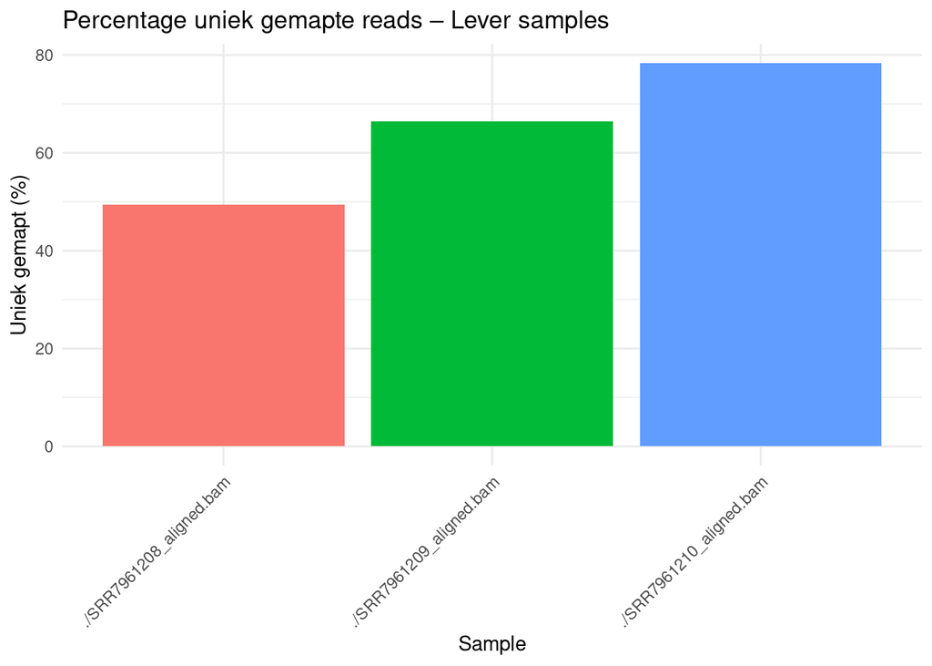

```
## [1] "./SRR7961208_aligned.bam" "./SRR7961209_aligned.bam"
## [3] "./SRR7961210_aligned.bam" "./SRR7961214_aligned.bam"
## [5] "./SRR7961215_aligned.bam" "./SRR7961216_aligned.bam"
```

```
##                     sample unique_reads...SRR7961208_aligned.bam
## 1 ./SRR7961208_aligned.bam                               7384081
## 2 ./SRR7961209_aligned.bam                               7384081
## 3 ./SRR7961210_aligned.bam                               7384081
##   unique_reads...SRR7961209_aligned.bam unique_reads...SRR7961210_aligned.bam
## 1                               9177388                              12224125
## 2                               9177388                              12224125
## 3                               9177388                              12224125
##   unique_reads...SRR7961214_aligned.bam unique_reads...SRR7961215_aligned.bam
## 1                              10768821                               5566898
## 2                              10768821                               5566898
## 3                              10768821                               5566898
##   unique_reads...SRR7961216_aligned.bam total_reads...SRR7961208_aligned.bam
## 1                               8707141                             14940927
## 2                               8707141                             14940927
## 3                               8707141                             14940927
##   total_reads...SRR7961209_aligned.bam total_reads...SRR7961210_aligned.bam
## 1                             13824967                             15602576
## 2                             13824967                             15602576
## 3                             13824967                             15602576
##   total_reads...SRR7961214_aligned.bam total_reads...SRR7961215_aligned.bam
## 1                             16278845                             20100959
## 2                             16278845                             20100959
## 3                             16278845                             20100959
##   total_reads...SRR7961216_aligned.bam percent_unique
## 1                             15368537        49.4218
## 2                             15368537        66.3827
## 3                             15368537        78.3468
```

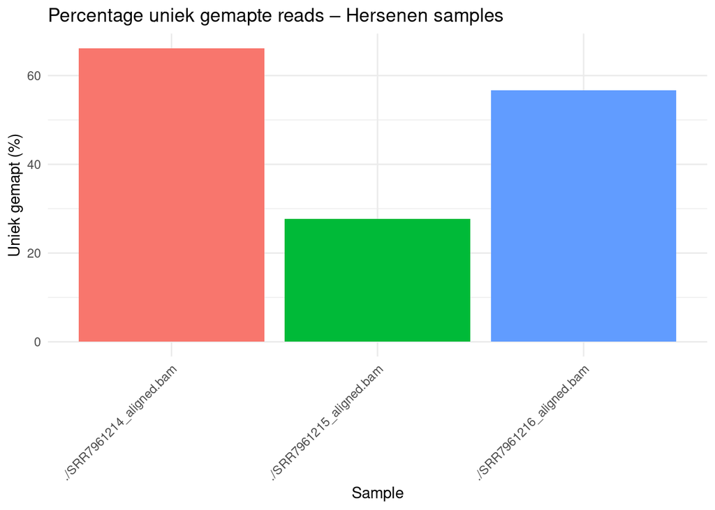

# Week4

[output not shown]

[output cut: 25 more lines]

```
## ||    Single-end reads are included.                                          ||
## ||    Total alignments : 20100959                                             ||
## ||    Successfully assigned alignments : 3530325 (17.6%)                      ||
## ||    Running time : 0.02 minutes                                             ||
## ||                                                                            ||
## || Process BAM file SRR7961216_aligned.bam...                                 ||
## ||    Single-end reads are included.                                          ||
## ||    Total alignments : 15368537                                             ||
## ||    Successfully assigned alignments : 4547113 (29.6%)                      ||
## ||    Running time : 0.02 minutes                                             ||
## ||                                                                            ||
## || Write the final count table.                                               ||
## || Write the read assignment summary.                                         ||
## ||                                                                            ||
## \\============================================================================//
```

```
## using ntop=500 top features by variance
```

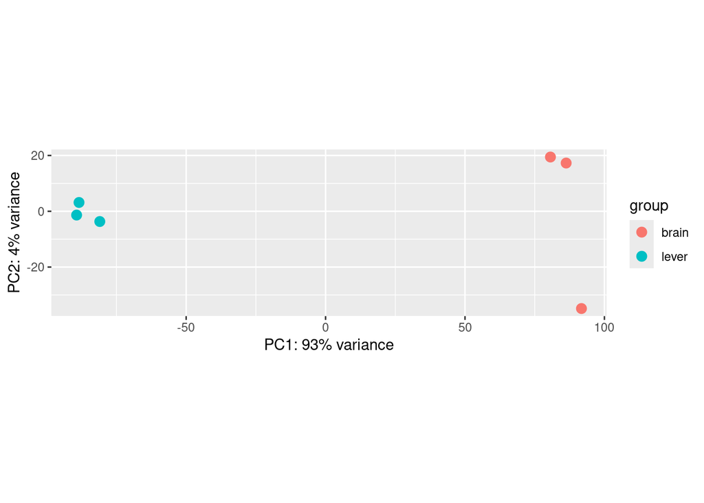

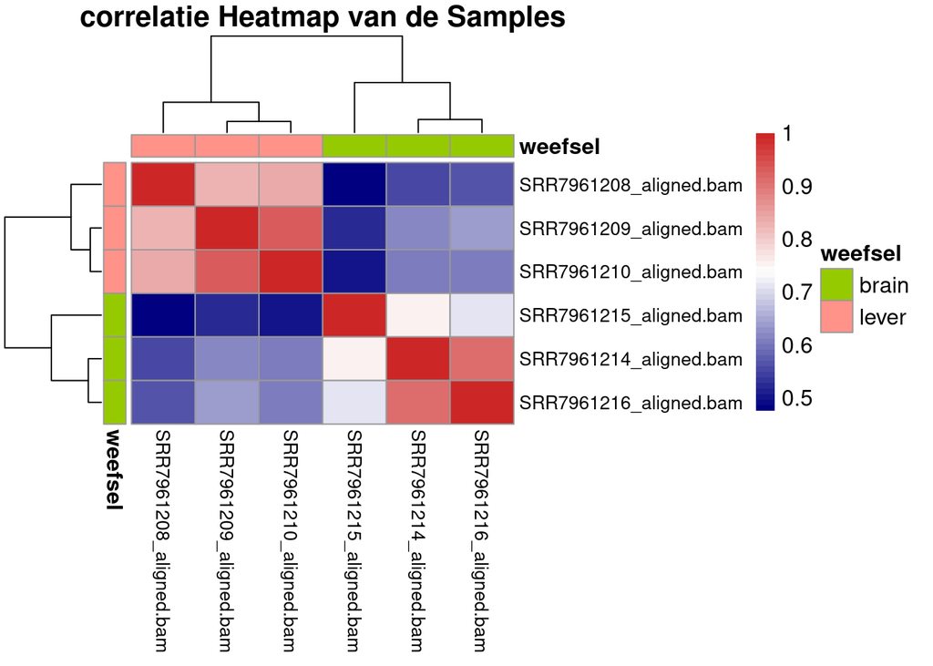

# Opdracht 5 inleiding.

In deze opdracht onderzoeken we welke genen verschillend tot expressie komen tussen leverweefsel en hersenweefsel. Met de ruwe count‑data bouwen we een DESeq2‑object waarin zowel de expressiewaarden als het design (lever vs. hersenen) zijn vastgelegd. Dit object vormt de basis voor de DGE analyse, waarbij voor elk gen de log2 fold change en de adjusted p‑waarde worden berekend om te bepalen of het gen hoger of lager tot expressie komt in één van de twee weefsels.

```
## log2 fold change (MLE): tissue lever vs brain
## Wald test p-value: tissue lever vs brain
## DataFrame with 6 rows and 6 columns
##       baseMean log2FoldChange     lfcSE      stat      pvalue        padj
##      <numeric>      <numeric> <numeric> <numeric>   <numeric>   <numeric>
## 2244  25150.52        11.3275  0.821847   13.7830 3.22585e-43 5.36169e-39
## 3273   7023.72        11.2554  0.838592   13.4218 4.50563e-41 3.74440e-37
## 2266  12771.99        11.4897  0.861010   13.3444 1.27726e-40 7.07645e-37
## 336   10423.62        11.4270  0.869977   13.1349 2.07821e-39 8.63550e-36
## 345    9943.45        11.4603  0.874358   13.1071 2.99801e-39 9.96599e-36
## 2243  35149.60        11.1535  0.854282   13.0560 5.87071e-39 1.62628e-35
```

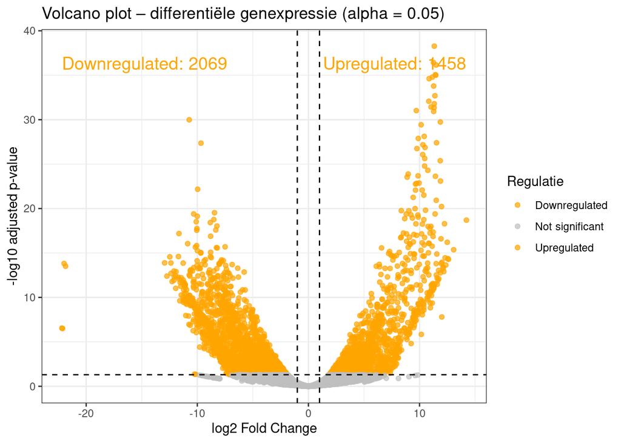

Deze volcano plot toont de differentiële genexpressie tussen hersenen en lever. Op de x‑as staat de log2 fold change, waarbij negatieve waarden genen aangeven die hoger tot expressie komen in de hersenen, en positieve waarden genen die hoger tot expressie komen in de lever. De y‑as geeft de –log10 van de aangepaste p‑waarde weer. De gestippelde lijnen markeren de drempelwaarden voor zowel de fold change als de p‑waarde. De oranje punten vertegenwoordigen de significant gereguleerde genen. Links in de grafiek staat het aantal down‑gereguleerde (hersenen‑specifieke) genen, en rechts het aantal up‑gereguleerde (lever‑specifieke) genen.

# Conclusie

Op basis van de differentiële expressieanalyse laten zowel de volcano plot als de heatmap zien dat er een duidelijk onderscheid bestaat tussen hersenen en lever op het niveau van genexpressie. De volcano plot toont dat een groot aantal genen significant verschillend tot expressie komt tussen beide weefsels, met meer dan tweeduizend genen die hoger tot expressie komen in de hersenen en ongeveer vijftienhonderd genen die hoger tot expressie komen in de lever. Dit bevestigt dat de twee weefsels sterk van elkaar verschillen in hun moleculaire functies.

Gezamenlijk bevestigen deze resultaten dat hersenen en lever sterk verschillende transcriptieprofielen hebben, wat overeenkomt met hun uiteenlopende biologische functies.